# Part II - (Prosper Data Exploration)

## by (Olalekan Ayinde)

## Investigation Overview

> The overview goal of the investigation is to investigate factors that contribute to high 'LenderYield' and loan approvals.

## Dataset Overview

> There are 113937 customers in the dataset with 81 features. We are focusing our exploration on about 10-15 features in the dataset. Most variables are numeric in nature, but the variable ProsperRating(Alpha) is an ordered factor variable with the corresponding numeric values captured in ProsperRating(Numeric). They have the following levels. (worst) ----> (best) ProsperRating(Alpha): HR, E, D, C, B, A, AA ProsperRating(Numeric): 1, 2, 3, 4, 5, 6, 7 Prosper as a company, considering the currency of this dataset (which was 2017), as 56,576 current loans that are running. About 38,074 ones have been completed, 5,018 defaulters while only 5 are cancelled.

## Distribution of 'LoanStatus' in the dataset

> The visualization will explore the distribution of 'LoanStatus' in the dataset. This shows how many customer of the company are in different range of 'LoanStatus'. Prosper as a company, considering the currency of this dataset (which was 2017), as 56,576 current loans that are running. About 38,074 ones have been completed, 5,018 defaulters while only 5 are cancelled.

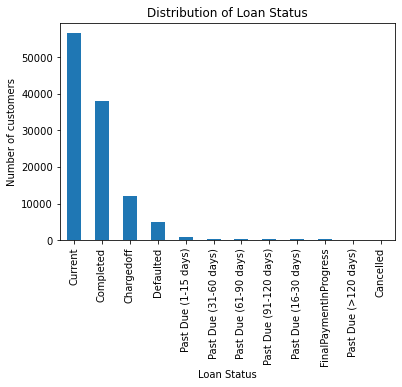

## Distibution of 'LenderYield' in the dataset.

> The visualization will explore the distribution of 'LenderYield' in the dataset. This is a right skewed histogram. This means that the mean > median > mode. This means that average lender yield is greater that median for all lender yield, which implies that the lenders could have more prospect investing in Prosper as a company.

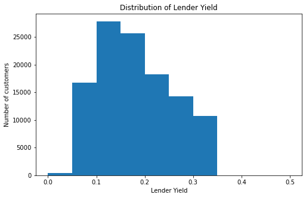

## Heatmap showing the correlation between the numeric variable of considerations.

> The visualization of heapmap for the correlation between the numeric values of consideration . As expected, a strong positive correlation exist between BorrowerAPR, LenderYield and EstimatedReturn. Borrower's APR, which is annual cost of a loan to a borrower-including fees, is dependent on the lender's yield and return on investment. The higher the borower's APR, the more money realised by the lenders.

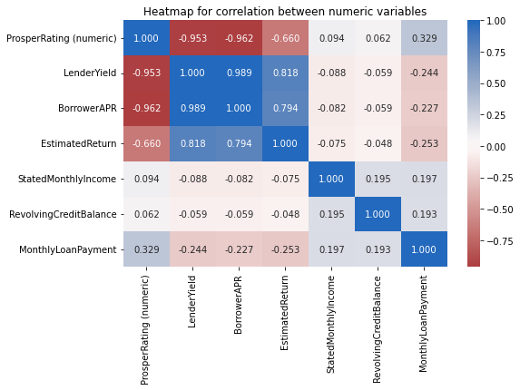

## 'BorrowerAPR' vs 'LenderYield'

> This plot suggest the concativity of the relationship between 'BorrowerAPR' and 'LenderYield'.

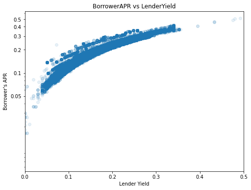

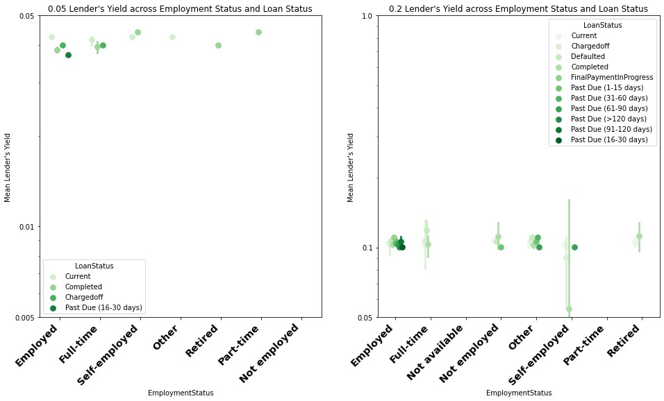